# project

# Summary

The following analysis uses a random forest prediction algorithm to accomplish this task, after some data cleaning. The results of the analysis confirm that the model provided by this algorithm achieves a high prediction accuracy (as indicated by several prediction quality indicators).

## Loading,Exploration and Cleaning

Let us begin by reading the pml-training.csv file into R. An initial inspection of the data shows that:

1.The data columns in the file are separated by commas. 2.There are many missing values. 3.The header line contains the names of the variables in the data set. 4.The first column is not really a variable, it just contains the row number.

```r
data<-read.csv("pml-training.csv")
dim(data)
```

```
## [1] 19622   160
```

```r
names(data)
```

```
##   [1] "X"                        "user_name"
##   [3] "raw_timestamp_part_1"     "raw_timestamp_part_2"
##   [5] "cvtd_timestamp"           "new_window"
##   [7] "num_window"               "roll_belt"
##   [9] "pitch_belt"               "yaw_belt"
##  [11] "total_accel_belt"         "kurtosis_roll_belt"
##  [13] "kurtosis_picth_belt"      "kurtosis_yaw_belt"
##  [15] "skewness_roll_belt"       "skewness_roll_belt.1"
##  [17] "skewness_yaw_belt"        "max_roll_belt"
##  [19] "max_picth_belt"           "max_yaw_belt"
##  [21] "min_roll_belt"            "min_pitch_belt"
##  [23] "min_yaw_belt"             "amplitude_roll_belt"
##  [25] "amplitude_pitch_belt"     "amplitude_yaw_belt"
##  [27] "var_total_accel_belt"     "avg_roll_belt"
##  [29] "stddev_roll_belt"         "var_roll_belt"
```

[output cut: 65 more lines]

As you can see, the datahas 19622 rows and 160 columns. Most of the variables correspond to sensor readings for one of the four sensors. Those sensor-reading variable names include one of the following strings to identify the corresponding sensor: _belt _arm _dumbbell _forearm The last column in the data frame (column 160) contains the values A to E of the classe variable that indicates the execution type of the exercise. Thus, the data in the first seven columns are not sensor readings. For the prediction purposes of this analysis, we will remove the data in those columns from the data frame.

```r
Columns = grep(pattern = "_belt|_arm|_dumbbell|_forearm", names(data))
clean1<-data[,c(Columns,160)]
dim(clean1)
```

```
## [1] 19622   153
```

Removing Columns having more than 19000 NA Values

```r
missingData = is.na(clean1)
removeColumns = which(colSums(missingData) > 19000)
clean2 = clean1[, -removeColumns]
dim(clean2)
```

```
## [1] 19622    86
```

```r
table(complete.cases(clean2))
```

```
##
##  TRUE
## 19622
```

## Data Splitting

```r
set.seed(7678)
library(caret)
inTrain <- createDataPartition(y=clean2$classe, p=0.75, list=FALSE)
training <- clean2[inTrain,]
dim(training)
```

```
## [1] 14718    86
```

```r
testing <- clean2[-inTrain,]
dim(testing)
```

```
## [1] 4904   86
```

1.We are going to apply random forests for classification. 2.We are not using pca here because we want to know the importance of each variable in this case.

## Training the Model

```r
library(randomForest)
model<-randomForest(as.factor(classe)~., data=training, ntree = 500)
```

## Applying the model on Test Set and calculating the error estimate

```r
prediction<-predict(model, newdata = testing)
testing$classe<-as.factor(testing$classe)
confusionMatrix(prediction, testing$classe)
```

```
## Confusion Matrix and Statistics
##
##           Reference
## Prediction    A    B    C    D    E
##          A 1394    7    0    0    0
##          B    1  939    4    0    0
##          C    0    3  850   13    0
##          D    0    0    1  790    2
##          E    0    0    0    1  899
##
## Overall Statistics
##
##                Accuracy : 0.9935
##                  95% CI : (0.9908, 0.9955)
##     No Information Rate : 0.2845
##     P-Value [Acc > NIR] : < 2.2e-16
##
##                   Kappa : 0.9917
##
##  Mcnemar's Test P-Value : NA
##
## Statistics by Class:
##
##                      Class: A Class: B Class: C Class: D Class: E
## Sensitivity            0.9993   0.9895   0.9942   0.9826   0.9978
## Specificity            0.9980   0.9987   0.9960   0.9993   0.9998
## Pos Pred Value         0.9950   0.9947   0.9815   0.9962   0.9989
## Neg Pred Value         0.9997   0.9975   0.9988   0.9966   0.9995
## Prevalence             0.2845   0.1935   0.1743   0.1639   0.1837
## Detection Rate         0.2843   0.1915   0.1733   0.1611   0.1833
## Detection Prevalence   0.2857   0.1925   0.1766   0.1617   0.1835
## Balanced Accuracy      0.9986   0.9941   0.9951   0.9909   0.9988
```

Both the accuracy and the kappa value indicate that the model seems to have a low out of sample error rate.

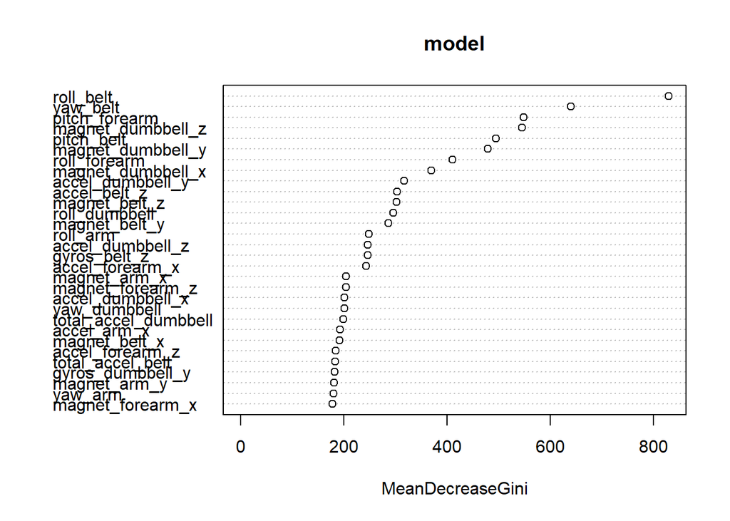

```r
varImpPlot(model)
```

Further, refining of model can be done according to the importance of each variable.